# NBA Shot Charts

Engel, Alec

7/19/2021

A shot chart in the NBA is a half court map showing where shooters most often shot the ball on the court for a given set of game data. Some shot charts may show field goal percentages of specific players against league averages, or simply individual shooting locations. Shot charts charts can be heavily utilized by a defending team to get a better idea of where most shots against will come from in particular situations. You can also look to defend players harder, call on a double team, or even look to foul an apposing player in specific areas of the court where we know they make a majority of their shots. The opposite approach may also be used of easing up on defensive pressure knowing that the player with the ball in his hands won’t shoot in specific areas due to past history and failure. These charts can also be used to help a player who may be struggling with specific areas of their game to shift focus towards training in weaker shot locations.

**Below are shooting charts from the 2018-2019 season of the Golden State Warriors, Houston Rockets, Los Angeles Lakers and Portland Trailblazers.**

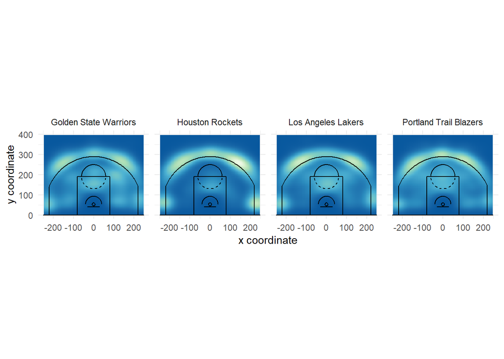

When looking at these shot charts side by side, we can see a strong tendencies for each team taking three pointers at the top of the arc. The Rockets look to be the heaviest perimeter shooting team with a majority of shots from outside and in the corners while having very little interior or mid range jump shots. The Warriors do take a decent amount of shots from deep as well, but we can also see a heavy concentration of their mid range two pointers from all over the court including in the paint. The Lakers and Trail Blazers also lean heavily on the three while taking many more interior and mid range shots in comparison to the Rockets.

**Below are shooting charts from the 2018-2019 season of Damian Lillard, James Harden, LeBron James and Stephen Curry**

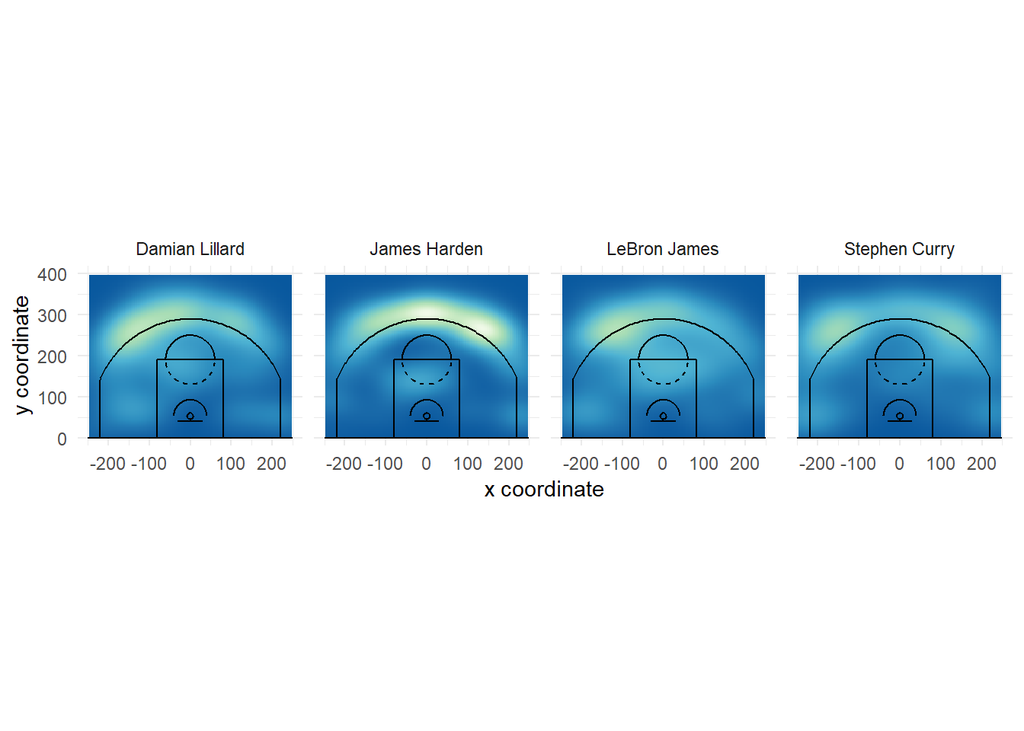

**Here we can see each of these player’s made vs. missed shots**

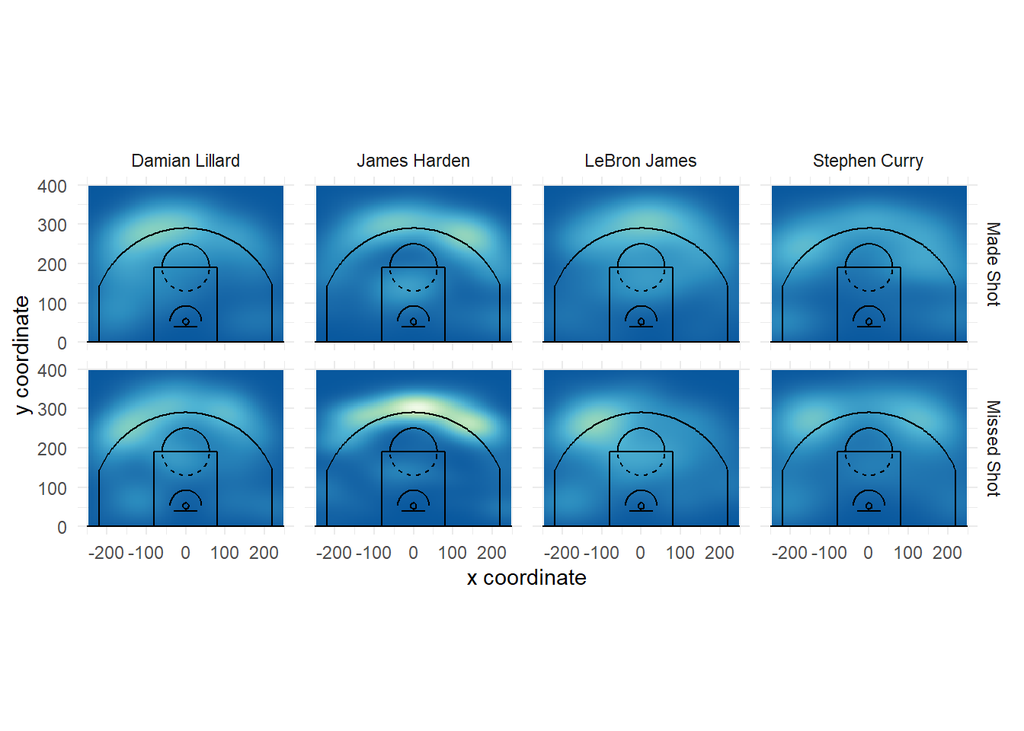

When focusing on made shots, we can see that Dame makes more of his three point shots from the top left of the arc, Harden from the top right, LeBron from the middle and Steph from all over. Harden and LeBron also look to make a decent amount of shots from in the paint around the freethrow line. When focusing on missed shots, we see similar patterns showing that these players have their comfortable shot locations on the court and aren’t afraid to keep shooting even if they are having an off night. Harden is again noticeable with the brightest hue from deep where it looks like he misses more shots than he makes at times but is not afraid to shoot. LeBron looks to miss more three pointers and mid range shots from the left side of the court so that could develop into a strategy of where to force shots from him when defending. Steph’s majority of missed shots look to be from well outside the three point line, but similar to the others, he definitely isn’t afraid to shoot from anywhere on the court. These shot charts are great examples of utilizing a heat map for where individual player’s shooting tendencies are during a game.